# Public Health and Economic Consequences of Natural Disasters

### Synopsis

In this report we aim to describe the public health and economic problems in the USA, caused by storms and other severe weather events, using data from the year **1950** to **2011** . Regarding Public health, ‘**Tornado**’ is the most harmful event, followed by ‘**Excessive Heat**’. Tornados are responsible for 65% of all injuries and 37.19% of all fatalities. And Regarding Economic damage, ‘**Flood**’ is the most economically damaging event. Floods alone have caused 31.5% of the total economic damage, and it is followed by ‘**Hurricane/Typhoon**’ and ‘**Tornado**’.

Loading the required packages into R:

```r
library(dplyr);
library(ggplot2);
library(xtable);
```

### Data Processing

We are using the U.S. National Oceanic and Atmospheric Administration’s (NOAA) storm database. The events in the database start in the year **1950** and end in **November 2011**.

#### Loading the dataset into R

```r
data <- read.csv("repdata_data_StormData.csv.bz2");
colnames(data);
```

```
##  [1] "STATE__"    "BGN_DATE"   "BGN_TIME"   "TIME_ZONE"  "COUNTY"
##  [6] "COUNTYNAME" "STATE"      "EVTYPE"     "BGN_RANGE"  "BGN_AZI"
## [11] "BGN_LOCATI" "END_DATE"   "END_TIME"   "COUNTY_END" "COUNTYENDN"
## [16] "END_RANGE"  "END_AZI"    "END_LOCATI" "LENGTH"     "WIDTH"
## [21] "F"          "MAG"        "FATALITIES" "INJURIES"   "PROPDMG"
## [26] "PROPDMGEXP" "CROPDMG"    "CROPDMGEXP" "WFO"        "STATEOFFIC"
## [31] "ZONENAMES"  "LATITUDE"   "LONGITUDE"  "LATITUDE_E" "LONGITUDE_"
## [36] "REMARKS"    "REFNUM"
```

#### Processing the data, to create a final dataset

This data needs to be processed in two ways:

- As seen above, the data containes 37 columns in total. For the purpose of this report, we are only interested in 8 of them. Hence we need to take a subset of the data, containing the following columns:
  1. “STATE”: The State that the event took place in.
  2. “EVTYPE”: Type of Event.
  3. “FATALITIES”: Number of Fatalities from the event
  4. “INJURIES”: Number of Injuries from the event
  5. “PROPDMG”: Property damage in USD
  6. “PROPDMGEXP”: Magnitude of property damage
  7. “CROPDMG”: Crop damage in USD
  8. “CROPDMGEXP”: Magnitude of crop damage
- There are two pairs of columns pertaining to the damage costs(“PROPDMG”, “PROPDMGEXP”, “CROPDMG”, “CROPDMGEXP”). For our final dataset, we need to combine each pair, into one single column, by multiplying the numeric value of the damage(eg. “PROPDMG”), to its magnitude/exponent(eg. “PROPDMGEXP” ).

We will begin by first creating the individual columns for each type of damage:

Before we multiply the *PROPDMG* and *CROPDMG* columns with the *PROPDMGEXP* and *CROPDMGEXP* columns respectively, we need to mutate the values of the *EXP columns, by replacing the characters and numbers in them, with their actual numeric values. Example: “B” = 10^9, “K” = 10^3, “5” = 10^5.

```r
prop_exp <- as.vector(data$PROPDMGEXP);
crop_exp <- as.vector(data$CROPDMGEXP);

# Loop through the vector, and mutate its values.
clean <- function(v) {

    for(i in 1:length(v)) {
        if (v[i] == "1") {
            v[i] <- "10";
        } else if (v[i] == "2" || v[i] == "H" || v[i] == "h") {
            v[i] <- "100";
        } else if (v[i] == "3" || v[i] == "K" || v[i] == "k") {
            v[i] <- "1000";
        } else if (v[i] == "4") {
            v[i] <- "10000";
        } else if (v[i] == "5") {
            v[i] <- "100000";
        } else if (v[i] == "6" || v[i] == "M" || v[i] == "m") {
            v[i] <- "1000000";
        } else if (v[i] == "7") {
            v[i] <- "10000000";
        } else if (v[i] == "8") {
            v[i] <- "100000000";
        } else if (v[i] == "B") {
            v[i] <- "1000000000";
        } else if (v[i] == "0"){
            v[i] <- "1";
        } else {
            v[i] <- NA;
        }
    }
    v
}

prop_exp <- as.integer(clean(prop_exp));
crop_exp <- as.integer(clean(crop_exp));
```

Now that we have mutated PROPDMGEXP and CROPDMGEXP columns, we can multiply them with PROPDMG and CROPDMG respectively, and get two columns: property damage and crop damage, the values of each one of them being the actual damage done in USD(eg. 25000). We can then add these two columns, to get a single column for the total damage done.

```r
PROPDMG <- data$PROPDMG * prop_exp;
CROPDMG <- data$CROPDMG * crop_exp;

prop_crop_dmg <- as.data.frame(cbind(PROPDMG, CROPDMG));

# Create a final data frame with PROPDMG, CROPDMG and total DMG. The total DMG needs
# to have the value of CROPDMG + PROPDMG, and needed to be manipulated in case
# CROPDMG and/or PROPDMG have NA's.

total_dmg <- mutate(prop_crop_dmg, DMG = ifelse(is.na(PROPDMG) & is.na(CROPDMG), NA,
                       (ifelse(is.na(PROPDMG), 0, PROPDMG)) +
                        (ifelse(is.na(CROPDMG), 0, CROPDMG))
));
```

**Creating the Final dataset**

We can now create our final dataset, by subsetting the necessary columns from the original dataset, and by adding the ‘*total_dmg*’ data frame we create above, to our final dataset. We will and print out the first 6 rows of the final dataset, to make sure everything worked properly. And then write the processed dataset into a file called ‘data.csv’

```r
data <- data[,c(7,8,23,24)];
data$PROPDMG <- total_dmg$PROPDMG;
data$CROPDMG <- total_dmg$CROPDMG;
data$DMG <- total_dmg$DMG;
head(data);
```

```
##   STATE  EVTYPE FATALITIES INJURIES PROPDMG CROPDMG   DMG
## 1    AL TORNADO          0       15   25000      NA 25000
## 2    AL TORNADO          0        0    2500      NA  2500
## 3    AL TORNADO          0        2   25000      NA 25000
## 4    AL TORNADO          0        2    2500      NA  2500
## 5    AL TORNADO          0        2    2500      NA  2500
## 6    AL TORNADO          0        6    2500      NA  2500
```

```r
nrow(data);
```

```
## [1] 902297
```

```r
write.csv(data, "data.csv");
```

### Results

#### 1. Across the United States, which types of events (as indicated in the ‘EVTYPE’ variable) are most harmful with respect to population health?

We create two data frames, *fatalities* and *injuries*. For each one of them, we aggregating the sum of its values, according to the type of event, and arrange it in the descending order.

```r
fatalities <- as.data.frame(arrange(aggregate(FATALITIES ~ EVTYPE, data, sum, na.rm=TRUE), desc
(FATALITIES)));

injuries <- as.data.frame(arrange(aggregate(INJURIES ~ EVTYPE, data, sum, na.rm=TRUE), desc(INJURIES
)));
```

Using the *fatalities* data frame from above, we can now create a table and a plot, of the top 6 most fatal events.

**Fatalities Table**:

```r
print(xtable(head(fatalities)), type="html");
```

|  | EVTYPE | FATALITIES |
| --- | --- | --- |
| 1 | TORNADO | 5633.00 |
| 2 | EXCESSIVE HEAT | 1903.00 |
| 3 | FLASH FLOOD | 978.00 |
| 4 | HEAT | 937.00 |
| 5 | LIGHTNING | 816.00 |
| 6 | TSTM WIND | 504.00 |

**Fatalities Plot**:

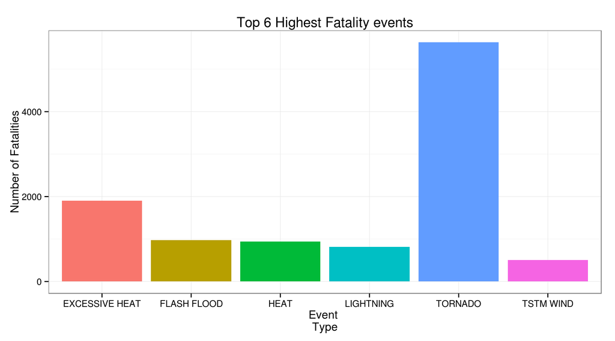

```r
ggplot(data = head(fatalities), aes(x = head(fatalities)$EVTYPE, y = head(fatalities)$FATALITIES)) +
geom_bar(stat = "identity") + theme(axis.text.x = element_text(angle = 90, hjust = 1)) + xlab("Event
Type") + ylab("Number of Fatalities") + ggtitle("Top 6 Highest Fatality events") + theme_bw() + aes(fill
= head(fatalities)$EVTYPE) + guides(fill=FALSE);
```

Similarly, using the *injuries* data frame, we can create a table and a plot of the top 6 events which created the most number of injuries.

**Injuries Table**:

```r
print(xtable(head(injuries)), type="html");
```

|  | EVTYPE | INJURIES |
| --- | --- | --- |
| 1 | TORNADO | 91346.00 |
| 2 | TSTM WIND | 6957.00 |
| 3 | FLOOD | 6789.00 |
| 4 | EXCESSIVE HEAT | 6525.00 |
| 5 | LIGHTNING | 5230.00 |
| 6 | HEAT | 2100.00 |

**Injuries Plot**:

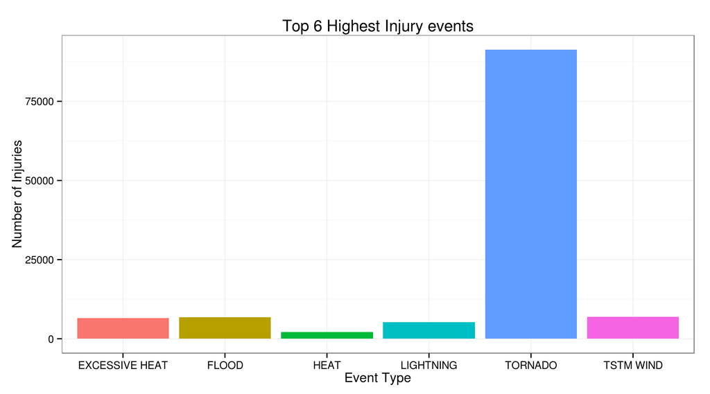

```r
ggplot(data = head(injuries), aes(x = head(injuries)$EVTYPE, y = head(injuries
)$INJURIES)) + geom_bar(stat = "identity") + theme(axis.text.x = element_text(
angle = 90, hjust = 1)) + xlab("Event Type") + ylab("Number of Injuries") +
ggtitle("Top 6 Highest Injury events") + theme_bw() + aes(fill
= head(injuries)$EVTYPE) + guides(fill=FALSE);
```

Getting the percentage of total injuries and fatalities caused by Tornado:

```r
sum_injuries <- sum(injuries$INJURIES);
sum_fatalities <- sum(fatalities$FATALITIES);

tornado_injuries <- (injuries$INJURIES[1]/sum_injuries)*100;
tornado_fatalities <- (fatalities$FATALITIES[1]/sum_fatalities)*100;
```

Percentage of the total Injuries caused by Tornado:

```r
#
paste(as.vector(tornado_injuries), "%", sep="");
```

```
## [1] "65.0019924854833%"
```

Percentage of the total Fatalities caused by Tornado:

```r
paste(as.vector(tornado_fatalities), "%", sep="");
```

```
## [1] "37.1937933311324%"
```

**Answer**

> It is clear from the tables and plots above, that **Tornado** is the most harmful event with respect to population health. Since 1950 to 2011, it is responsible for 91346 injuries(65% of the total injuries), and 5633 fatalities(37.19% of the total fatalites), placing it at the No.1 position of both tables. **Excessive Heat** is also a dangerous event, it has caused a total of 1903 fatalities and 6525 injuries, making it No.2 on the fatalities table and No.4 on the injuries table.

#### 2. Across the United States, which types of events have the greatest economic consequences?

We create a data frame, called *dmg*, by aggregating the sum of the Net Economic Damage, according to the event type, and arrange it in the in the descending order.

```r
dmg <- as.data.frame(arrange(aggregate(DMG ~ EVTYPE, data, sum, na.rm=TRUE),
desc(DMG)));
```

Using the *dmg* data frame, we can now create a table and a plot, of the total economic damage done by the top 6, most damaging events.

**Table of Total Economic Damage**

```r
print(xtable(head(dmg)), type="html");
```

|  | EVTYPE | DMG |
| --- | --- | --- |
| 1 | FLOOD | 150319678250.00 |
| 2 | HURRICANE/TYPHOON | 71913712800.00 |
| 3 | TORNADO | 57362333883.50 |
| 4 | STORM SURGE | 43323541000.00 |
| 5 | HAIL | 18761221925.70 |
| 6 | FLASH FLOOD | 18243990871.50 |

**Plot of Total Economic Damage**

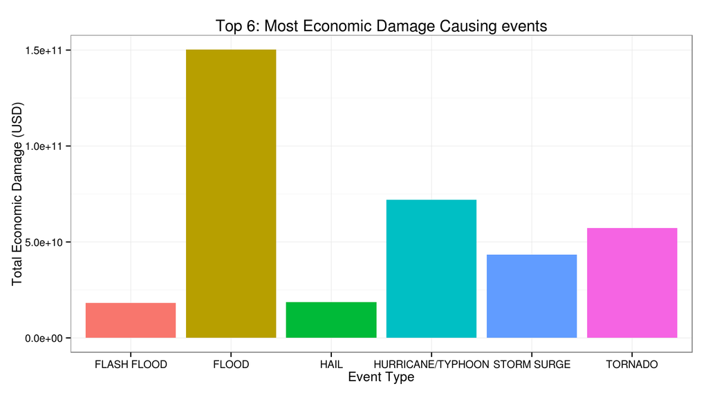

```r
ggplot(data = head(dmg), aes(x = head(dmg)$EVTYPE, y = head(dmg)$DMG)) +
geom_bar(stat = "identity") + theme(axis.text.x = element_text(angle = 90,
hjust = 1)) + xlab("Event Type") + ylab("Total Economic Damage (USD)") +
ggtitle("Top 6: Most Economic Damage Causing events") + theme_bw() + aes(fill
= head(dmg)$EVTYPE) + guides(fill=FALSE);
```

**Percentage of the Total Damage caused by Flood, HURRICANE/TYPHOON and TORNADO**

```r
total_dmg <- sum(dmg$DMG);

flood_dmg <- (dmg$DMG[1]/total_dmg)*100;
hurricane_dmg <- (dmg$DMG[2]/total_dmg)*100;
tornado_dmg <- (dmg$DMG[3]/total_dmg)*100;
```

Total Damage in USD:

```r
paste(as.vector(total_dmg),"USD", sep=" ");
```

```
## [1] "477329060278.3 USD"
```

Percentage of the total damage due to Flood:

```r
paste(as.vector(flood_dmg),"%",sep="");
```

```
## [1] "31.4918346187341%"
```

Percentage of the total damage due to Hurricane/Typhoon:

```r
paste(as.vector(hurricane_dmg),"%",sep="");
```

```
## [1] "15.065856823817%"
```

Percentage of the total damage due to Tornado:

```r
paste(as.vector(tornado_dmg),"%",sep="");
```

```
## [1] "12.0173562971539%"
```

**Answer**

> As seen from the table and the plot above. **Flood** is the most Economically damaging event, and from 1950 to 2011, out of the total 477.33 Billion USD of damage, Flood alone has caused damage of around 150.32 Billion USD(31.5% of the total damage). It is followed by **Hurricane/Typhoon** and **Tornado** which have caused damages worth 71.91 Billion USD(15% of the total damage), and 57.36 Billion USD(12% of the total damage), respectively.